# **RBSI Visualization and Interpretation Lab**

### Boxplots

We can also create boxplots which are useful to describe our data.

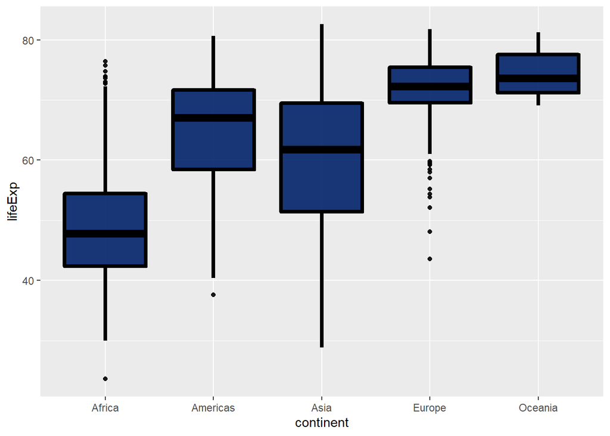

```r
ggplot(data=gapminder,
       aes(y=lifeExp, x=continent)) +
   geom_boxplot(fill="#012169",
                 color="black",
                 size=1.5,
                 alpha=.9)
```

### Lines

Sometimes using lines to connect the dots might be helpful to see some patters in the data.Let’s look at the GDP per capita for each country across time in each continent.

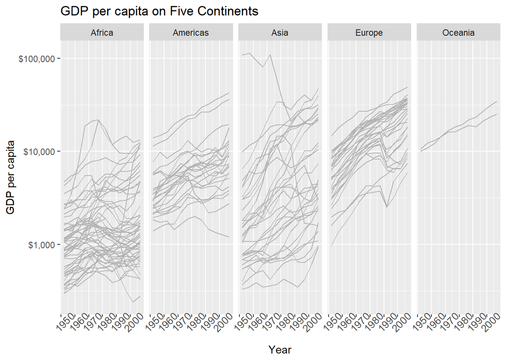

```r
p4 <- ggplot(data = gapminder,                                   # Data
             mapping = aes(x = year, y = gdpPercap)) +           # Variables for the x and y axis
   geom_line(color="gray70",                                     # using geom_line to add lines
             aes(group = country)) +                             # grouping info by country
    scale_y_log10(labels=scales::dollar) +                       # Transform the GDP with a log function to control for very big income earners
    facet_wrap(~ continent, ncol = 5) +                          # We want 5 panels one for each continent in 5 columns
    labs(x = "Year",                                             # Labels
         y = "GDP per capita",
         title = "GDP per capita on Five Continents") +
   theme(axis.text.x = element_text(size = 10, angle = 45))      # Changing the size and angle of the x-axis ticks
p4
```

## **Interpreting and Graphing OLS Results**:

Now, we are changing gears a bit to learn how to graph and interpret regression results. We are going to use an old cleaned dataset from the 2016 ANES. We will try to understand some of the determinants of voting. You can find in Sakai a csv file called *lab_Visualization_Data* that we are going to use today. This file contains seven variables and 2762 observations from the 2016 ANES. The variables are as follows:

- *Vote*: Indicator variable if the individual casted a vote
- *Black*: Indicator variable if the individual self-identified as black
- *Hisp*: Indicator variable if the individual self-identified as hispanic
- *pid7*: 7-point partisan identification scale
- *income*: income category for the respondent
- *age*: age of the respondent at the time of the survey
- *educ_attain*: Highest educational attainment from the individual at the time of the survey

For this part of the lab, we will run a linear probability model (LPM). Logit and probit models can also be used to estimate dichotomous variables. However, for ease of interpretation, we will be going with an LPM. If you want to know more about logit and probit models come to OH.

```r
# load your data and make it in a data frame format. Always include the extension at the end of the file.
# Remember to set your working directory!
anes <- as.data.frame(read.csv("lab_Visualization_Data.csv"))
# Run your model
m1 <- lm(vote ~ black + hisp + pid7 + income + age + educ_attain, data = anes)
```

### Using ggplot

For most coefplots, we will need to create a placeholder matrix and then use the graphing functions and attributes we have seen. You can also use base R instead of ggplot to produce these kind of graphs. If you are interested in learning how to do this. Let us know and we can go through some code together. This placeholder matrix will be a “small dataset” with the coefficients, standard errors and confidence intervals to graph later.

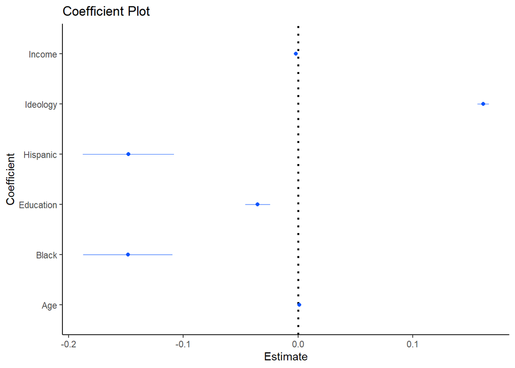

```r
# Run your model
out <- summary(m1)                                                                    # Create a placeholder for the summary results
n <- nrow(out$coefficients)                                                           # Number of coefficients in the model
# Create a placeholder matrix, make sure you have
coefMat <- matrix(NA, n-1, 4)
coefMat[,1] <- out$coefficients[2:n,1]
coefMat[,2] <- out$coefficients[2:n,2]
coefMat[,3] <- coefMat[,1] - qnorm(1-0.05/2)*coefMat[,2]
coefMat[,4] <- coefMat[,1] + qnorm(1-0.05/2)*coefMat[,2]
rownames(coefMat) <- c("Black", "Hispanic", "Ideology", "Income", "Age", "Education")
colnames(coefMat) <- c("coef", "std_err", "min", "max")
df <- as.data.frame(coefMat)
# Plot
coefplot <- ggplot(data = df, aes(x = rownames(coefMat),
                           y = coef)) +
   geom_hline(yintercept=0, colour="black", size=1, linetype="dotted") +
   geom_linerange(aes(ymin=min, ymax=max), size=0.2, color="#0a55fd") +
   geom_point(color="#0a55fd") +
   labs(x="Coefficient", y="Estimate", title="Coefficient Plot") +
   coord_flip() + theme_classic()

coefplot
```

### Using the canned function coefplot from the arm package

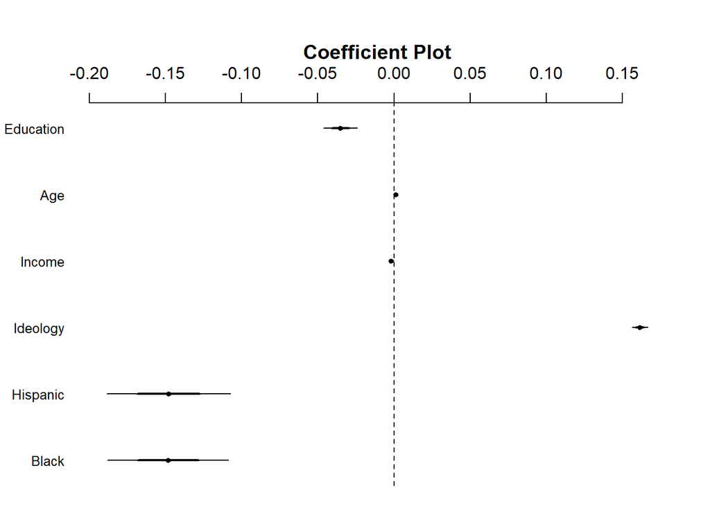

I prefer to use ggplot or basic R since it is easier to customize than coefplot.

### Some interpretations

In our model, we are using a dichotomous dependent variable. Thus, the “units” will be know as percentage points which is different to percentages. Also, unless you have a causal framework it is better to talk about correlations and not clear effects. Finally, all interpretations are under the assumption that all the other parts of the model remain constant (ceteris paribus). Let’s see the results’ summary for our model:

```
##
## Call:
## lm(formula = vote ~ black + hisp + pid7 + income + age + educ_attain,
##     data = anes)
##
## Residuals:
##      Min       1Q   Median       3Q      Max
## -1.09073 -0.11941 -0.00022  0.13576  1.10610
##
## Coefficients:
##               Estimate Std. Error t value Pr(>|t|)
## (Intercept) -0.0268481  0.0286790  -0.936  0.34927
## black       -0.1483469  0.0198518  -7.473 1.05e-13 ***
## hisp        -0.1480181  0.0203096  -7.288 4.09e-13 ***
## pid7         0.1613291  0.0025796  62.540  < 2e-16 ***
## income      -0.0018957  0.0007788  -2.434  0.01499 *
## age          0.0010460  0.0003322   3.149  0.00166 **
## educ_attain -0.0352180  0.0055525  -6.343 2.63e-10 ***
## ---
## Signif. codes:  0 '***' 0.001 '**' 0.01 '*' 0.05 '.' 0.1 ' ' 1
##
## Residual standard error: 0.2943 on 2755 degrees of freedom
## Multiple R-squared:  0.6522, Adjusted R-squared:  0.6514
## F-statistic: 860.9 on 6 and 2755 DF,  p-value: < 2.2e-16
```

$$vote_i = \beta_0 +\beta_1hisp_i + \beta_2 income_i + \beta_3 hisp_i\times income_i + \epsilon_i$$
In this case:

- the average effect of being hispanic is: $Pr(vote_i | hisp=1) = \beta_0 +\beta_1 + \beta_2 income_i + \beta_3 income + \epsilon_i$.
- the average effect of not being hispanic is: $Pr(vote_i | hisp=0) = \beta_0 + \beta_2 income_i + \epsilon_i$
- $\beta_1$ is the effect of hispanic at no levels of income (not so telling)
- $\beta_2$ is the effect of income for non-hispanics
- $\beta_3$ is the interaction effect, it is the marginal effect of being hispanic at each level of income

```r
m2 <- lm(vote ~ hisp*income, data = anes)
summary(m2)
```

```
##
## Call:
## lm(formula = vote ~ hisp * income, data = anes)
##
## Residuals:
##     Min      1Q  Median      3Q     Max
## -0.4954 -0.4834 -0.2215  0.5146  0.8453
##
## Coefficients:
##               Estimate Std. Error t value Pr(>|t|)
## (Intercept)  0.4674114  0.0221477  21.104  < 2e-16 ***
## hisp        -0.3175110  0.0665398  -4.772 1.92e-06 ***
## income       0.0009998  0.0012345   0.810    0.418
## hisp:income  0.0037767  0.0040737   0.927    0.354
## ---
## Signif. codes:  0 '***' 0.001 '**' 0.01 '*' 0.05 '.' 0.1 ' ' 1
##
## Residual standard error: 0.4926 on 2758 degrees of freedom
## Multiple R-squared:  0.02425,    Adjusted R-squared:  0.02318
## F-statistic: 22.84 on 3 and 2758 DF,  p-value: 1.324e-14
```

### Marginal Effect Plots

We can also do plots to show the effects of interactions. These are usually known as marginal effect plots. For this, we need to create a new placeholder object, but it is a bit more complicated. Notably, because we need to use the results of our models to predict the values of voting and see how they change at different levels of a determined running variable.

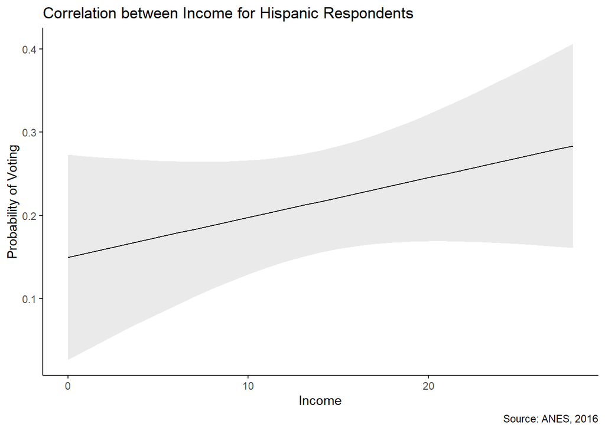

```r
# First, create the prediction data
# The prediction data is going to be a a 5X2 matrix for rows equal to the values of the running variable and columns equal to the number of variables in our model. Be super careful about the order of the elements.
n <- length(unique(anes$income))
prediction_data <- data.frame(hisp = rep(1,n),
                              income = 0:(n-1))
# Predict the probability of voting with the results of our model using predict
predvals <- predict(m2,                                            # model used
                    type="response",                               # type of response, see ?predict for multiple outputs
                    se.fit=T,                                      # tell the function you want the standard errors as well
                    newdata = prediction_data)                     # if using a newdataset for predictions, which data is that

# Create the standard errors and the values for each level of income and then make them a dataframe
income <- 0:28
fit <- predvals$fit
lowCI <- predvals$fit - qnorm(1-0.05/2)*predvals$se.fit
highCI <- predvals$fit + qnorm(1-0.05/2)*predvals$se.fit
effects <- as.data.frame(cbind(income, fit, lowCI, highCI))

# Plot
margplot <- ggplot(data = effects, aes(x = income,
                                       y = fit)) +
   geom_line() +
   geom_ribbon(aes(ymin = lowCI, ymax = highCI), alpha = .1) +
   labs(x = "Income",
        y = "Probability of Voting",
        title = "Correlation between Income for Hispanic Respondents",
        caption = "Source: ANES, 2016") +
   theme_classic()

margplot
```

There are also some canned functions we could use to calculate the marginal effects. One of them is the *ggeffects* package. Let’s see how it works.

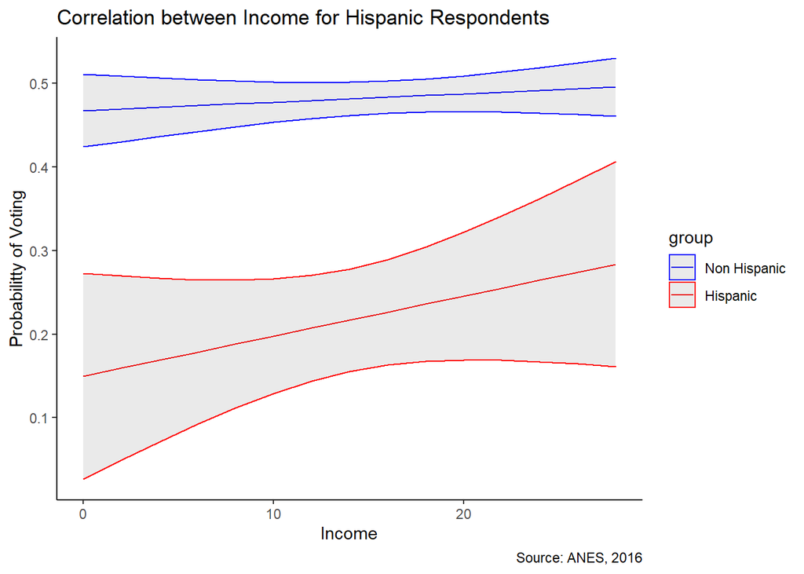

```r
# You will need to install and then load the ggeffects package
library(ggeffects)
# Create an object holder for the predictions
effects <- ggpredict(m2,                                            # model
                     terms = c("income", "hisp"))                   # variables you want to graph
p5 <- ggplot(effects, aes(x = x, y = predicted, color = group)) +
   geom_line() +
   geom_ribbon(aes(ymin = conf.low, ymax = conf.high), alpha = .1) +
   scale_color_manual(labels = c("Non Hispanic", "Hispanic"), values = c("blue", "red")) +
      labs(x = "Income",
        y = "Probabilitty of Voting",
        title = "Correlation between Income for Hispanic Respondents",
        caption = "Source: ANES, 2016") +
   theme_classic()
p5
```

## **Some additional resources**

1. There is a whole art behind visualization and making graphs in R. Here are some links that might be useful when producing different visualizations of your data.
   - I found the Computational Social Science webpages from [Tiago Ventura](https://tiagoventura.rbind.io/teaching/), [Yae Jeon Kim](https://jaeyk.github.io/PS239T/) and Summer Institute of Computational Social Science [(SICSS)](https://sicss.io/boot_camp) useful for the elaboration of this lab. Some of the examples are the same and others are inspired on them.
   - I also highly recommend Kieran Healy’s [book](https://socviz.co/index.html#preface) on Data Visualization using ggplot.
   - There is also a ggplot [cheat sheet](https://github.com/rstudio/cheatsheets/blob/master/data-visualization-2.1.pdf) that is always handy.
   - Here are some ggplot visualization [examples](http://r-statistics.co/Top50-Ggplot2-Visualizations-MasterList-R-Code.html)